# Epigenomics

Anoob Prakash

25/03/2020

# The experiment

## Learning objectives:

1. Background on the copepod selection experimental design
2. Think about the hypotheses we can address with this experiment
3. Cover how bisulfite sequencing data differs from regular data and not to panic when you see your fastqc output
4. Begin mapping using Bismark

## Copepod selection experiment

Acartia tonsa is a calanoid copepod that has a world wide distribution. It inhabits estuaries and coastal waters and it typically the most abundant zooplankton present. Because of their huge population sizes and global distribution, they play an important role in ocean biogeochemical cycling and ecosystem functioning. For example, they’re an important food base for many fishes. Given their broad distribution in dynamic habitats (estuaries), they can tolerate and live in a broad range of salinities, freshwater to seawater, and temperatures, among other stressors.

We know that the world is rapidly changing due to human activities and it is important to understand how species will respond to these changes. We were interested in understanding how A. tonsa could respond to stressful environments that will likely be caused by climate change. Can they adapt to rapid changes in temperature and acidity? How might epigenetic responses interact with adaptation to enable resilience?

A. tonsa is a great system to ask these questions for a number of reasons. First, their generation time is only ~10-20 days and they’re tiny! Only 1-2 mm. This means we can easily execute multi-generational studies with thousands of individuals. Second, because they can tolerate such variable environments, they should have lots of plasticity to respond to environmental fluctuations. Finally, their large population sizes mean that genetic diversity should be high, giving them high adaptive potential. This means that if any species can respond to rapid environmental change, it is likely A. tonsa.

## Experimental design

A. tonsa were collected from the wild, common gardened for three generations, and then split into **four treatments** with **four replicates** each and about 3,000-5,000 individuals per replicate. They were left to evolve in these conditions for **25 generations**. Samples were collected at generation F0 and F25 to quantify methylation frequencies using **reduced representation bisulfite sequencing** [(RRBS)](https://en.wikipedia.org/wiki/Reduced_representation_bisulfite_sequencing).

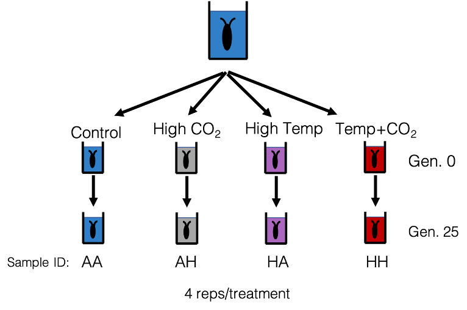

The experimental design

| Sample ID | Treatment | Trt abrreviation | Generation |
| --- | --- | --- | --- |
| AA_F00_1 | Control: ambient temp, ambient CO2 | AA | F00 |
| AA_F25_2 | Control: ambient temp, ambient CO2 | AA | F25 |
| AH_F25_3 | ambient temp, high CO2 | AH | F25 |
| HA_F25_1 | high temp, ambient CO2 | HA | F25 |
| HH_F25_1 | high temp, high CO2 | HH | F25 |

## RRBS

- Stands for reduced representation bisulfite sequencing
- Following the adapter ligation, we bisulfite convert all unmethylated C’s to T’s.
- Before starting we also spiked in a small amount of DNA from E. coli that we know wasn’t methylated. Using this, we can calculate downstream how efficient our bisulfite conversion was.

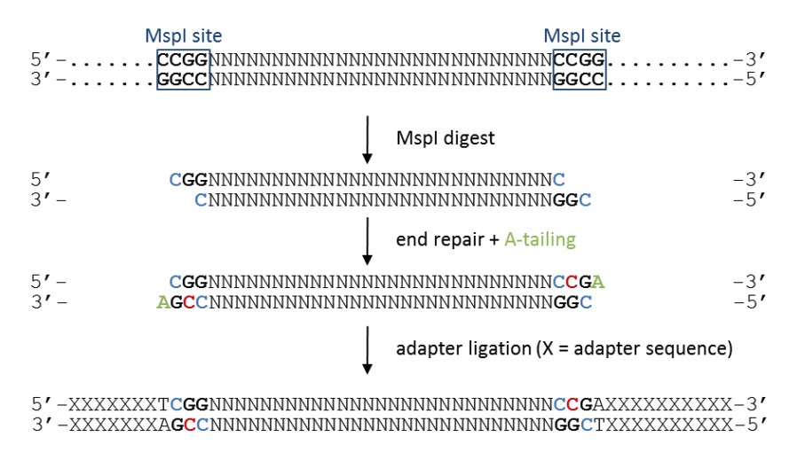

How RRBS works

## methylKit capabilities

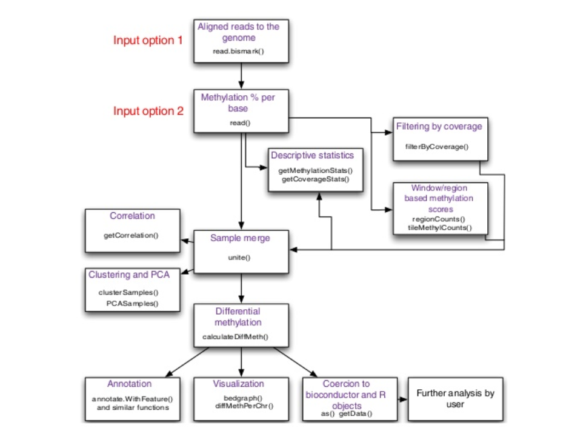

Flowchart for capabilities of methylKit package

# Pipeline

1. Visualize, clean, visualize
- Visualize quality of raw data with fastqc
- clean raw data with Trimmomatic
- Visualize quality of cleaned data with fastqc
2. Align to Acartia tonsa reference genome (**Bismark**)
- also align lambda DNA to check for conversion efficiency (Already Done)
3. Extract methylation calls
4. Process and filter calls
5. Summary figures (PCA, clustering, etc)
6. Test for differential methylation (Methylkit)

## Bisulfite sequence data looks weird

Unlike the normal sequence reads, in bisulfite conversion there is a high no. of T bases. This increase is because of the fact that all the non-methylated cytosines are converted to thyamine bases. While the that the reverse strand is the reverse complement of the bisulfite converted forward strand, and is not just the BS converted bottom strand. Thus reverse read being complement to the forward read will have a higher no. of adenine bases.

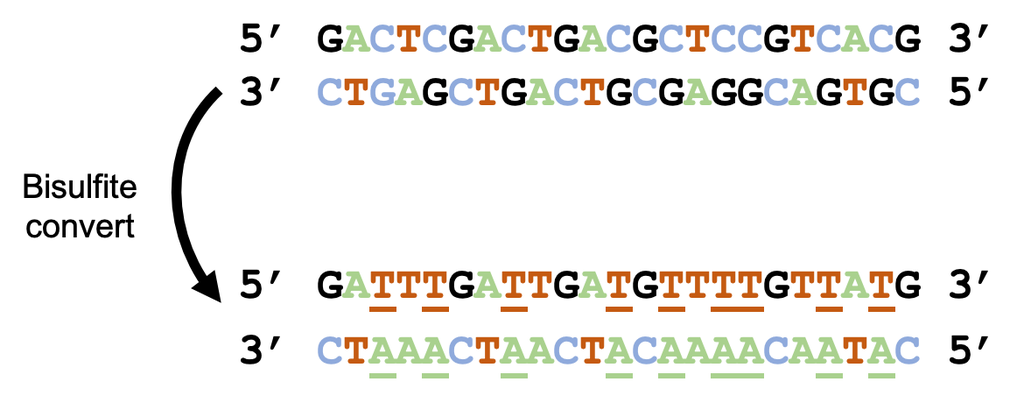

Why bisulfite fastq visualization looks weird

## FastQ report

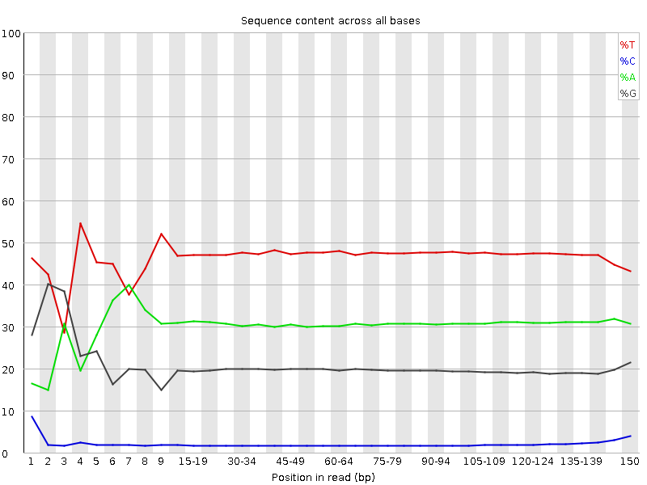

FastQ for the bisulfite convereted forward read after trimming

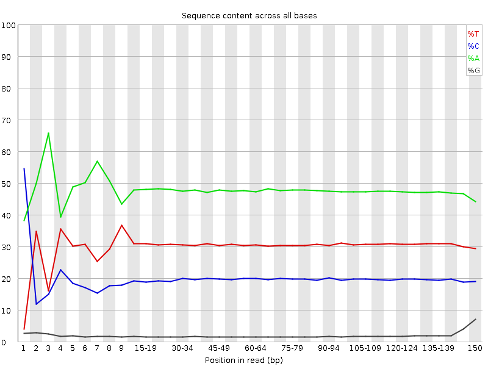

FastQ for the bisulfite convereted reverse read after trimming

# Bismark

- Align to Acartia tonsa reference genome using Bismark

**Location of data stored:**  
cd /data/project_data/epigenetics/reference_genome/Bisulfite_Genome/

**Sample assigned**  
- AH_F25_4

## Bash code

- type bismark in bash to start the program
- `bismark -help` for help with the wrapper
- `--output_dir` - one output directory for all the data
- forward read are - _1
- reverese reads are - _2
- adding read group
  - `--rg_tag`
  - `--rg_id` - sample id
- `--gzip` - compress
- `--local` - local alignment / soft clipping of the bases
- `--maxins` - max insert size

```bash
#!/bin/bash

bismark --bowtie2 --multicore 1 \
    --genome /data/project_data/epigenetics/reference_genome \
    --output_dir /data/project_data/epigenetics/aligned_output \
    -1 /data/project_data/epigenetics/trimmed_fastq/AH_F25_4_1.fq.gz \
    -2 /data/project_data/epigenetics/trimmed_fastq/AH_F25_4_2.fq.gz \
    --rg_tag --rg_id AH_F25_4 --rg_sample AH_F25_4 --gzip --local --maxins 1000
```

Bismark is, at its core, running [`bowtie2`](http://bowtie-bio.sourceforge.net/bowtie2/index.shtml). But there are important differences. If you remember, we’re using two modified versions of the genome where we’ve converted C-to-T AND G-to-A. We also generate temporary files of our trimmed reads where we convert C-to-T (read1) AND G-to-A (read2) so they can map to this converted genome. This makes the alignment a bit harder because : 1. the complexity of DNA is reduced  
2. we are mapping to two separate genomes.

**Parameters**

`--bowtie2` tells bismark to map with bowtie2. There are other options possible here (bowtie1, for example)

`--multicore 1` Use one core. We could use multiple cores to make alignment faster, but we may crash the server if many of you are mapping at once if we do this.

`--rg_tag` add a read group tag that identifies your individual sample in your output bam file

`--rg_id` the string that defines the readgroup ID

`--rg_sample` the string that defines your readgroup sample ID  
`--gzip` for the temporary files, use gzip to save space  
`--local` align with the local alignment option in bowtie2. This will include soft clipping, which should increase mapping rate, but comes at the cost of (maybe) increasing mis-mapping.

`--maxins` specifies the maximum insert size for mapping. We’re using 1000 as our libraries had a mean insert size of ~200. Note that this is smaller than most sequencing libraries.

```bash
#!/bin/bash

bismark --bowtie2 --multicore 1 \
    --genome /data/project_data/epigenetics/reference_genome \
    --output_dir /data/project_data/epigenetics/aligned_output \
    -1 /data/project_data/epigenetics/trimmed_fastq/SAMPLEID_1.fq.gz \
    -2 /data/project_data/epigenetics/trimmed_fastq/SAMPLEID_2.fq.gz \
    --rg_tag --rg_id SAMPLEID --rg_sample SAMPLEID --gzip --local --maxins 1000
```

Here the SAMPLEID was replaced with my sample id `AH_F25_4`

## Mapping reads

- zcat to read the .gz files

On Mac, use the following: zcat < AA_F00_1_1_bismark_bt2_pe.bismark.cov.gz

**Mapping rate**  
- The mapping rate is very high in AA_F00, the control at zero generations, which can be worrying. This might be due to the fact that slightly more samples went into sequecing AA_F00.  
- So including more DNAs might actually help increase the mapping rate.  
- Maybe mapping them as single ends rather than paired end might help increase the mapping rate.  
- THe bisulfite conversion rate was checked and found out to be 98-99%, when compared with the *E.coli* that was spiked in.

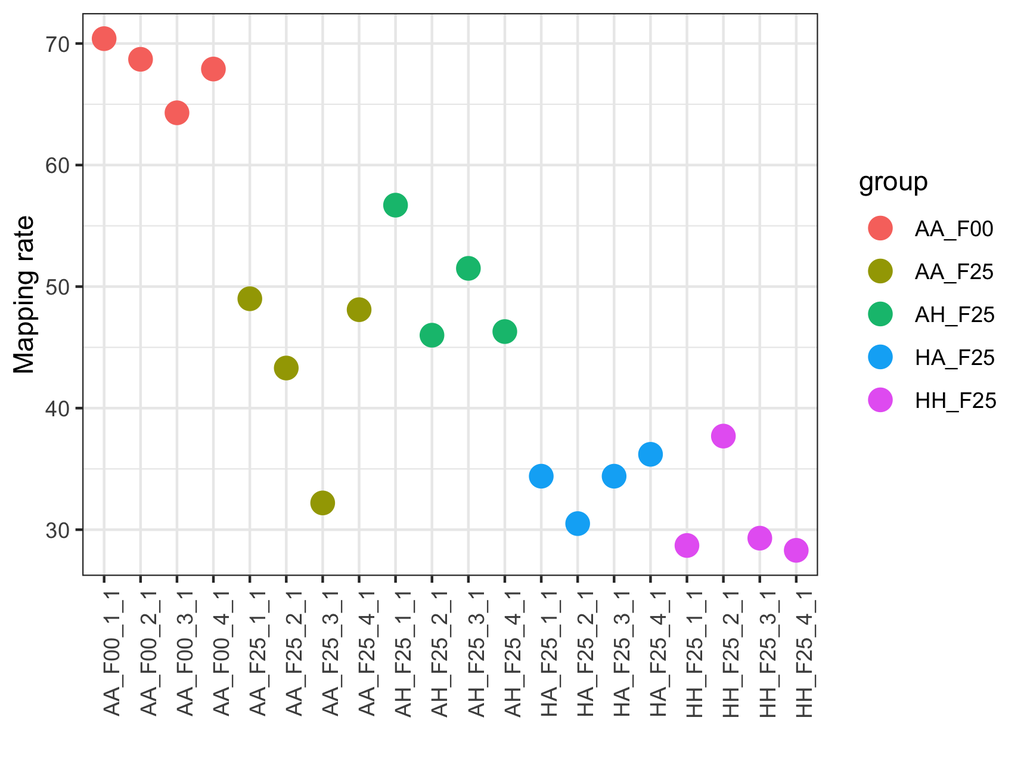

Mapping rates for different treatements

# Extract methylation calls

## Methylation report

```bash
bismark_methylation_extractor --bedGraph --scaffolds --gzip \
    --cytosine_report --comprehensive \
    --no_header \
    --parallel 6 \
    --output ~/tonsa_epigenetics/analysis/methylation_extract/ \
    --genome_folder /data/copepods/tonsa_genome/ \
    *pe.bam
```

[Methylation extraction report](https://htmlpreview.github.io/?https://github.com/PespeniLab/Ecological-Genomics/blob/master/Epigenetics_AA_F00_2_1_bismark_bt2_PE_report-ALL_SITES.html)

**M-Bias Plot**  
- Methylation Bias Plot  
- CpG methylation is the dark line across the length of the read, and we are intersted in this line  
- CpG methylation is same across the read, which is what we expect to see  
- CpG reads are very high at the begining for *read 1*, we are unsure of what it is so we are going to **cut the first two bases** to remove this bias.  
- It is generally recommended to remove this bias  
- The same spike was also seen in the spiked E.coli  
- The mechanism that is causing it is very unclear  
- Generally considered as a technical artifact rather than a biological artifact  
- *Read 2* shows a bit of a dip in CpG at the beginning

## Methylation report ignoring bias

**To ignore the first two bases:**  
- Done to remove the high CpG read at the begining of the reads

```bash
bismark_methylation_extractor --bedGraph --scaffolds --gzip \
    --cytosine_report --comprehensive \
    --no_header \
    --parallel 6 \
    --ignore 2 --ignore_r2 2 \
    # this says to ignore the first two bases
    --output ~/tonsa_epigenetics/analysis/methylation_extract/ \
    --genome_folder /data/copepods/tonsa_genome/ \
    *pe.bam
```

[Methylation extraction report ignoring bias](https://htmlpreview.github.io/?https://github.com/PespeniLab/Ecological-Genomics/blob/master/Epigenetics_AA_F00_2_1_bismark_bt2_PE_report-IGNORE_BIAS.html)

## bash

We can look at sites with some data using the following:

```bash
zcat HH_F25_4_1_bismark_bt2_pe.bismark.cov.gz | head
```

Column 1: Chromosome  
Column 2: Start position  
Column 3: End position  
- Both start and stop column of the base we are intersted in are going to be same, since we are looking at single bases  
Column 4: Methylation percentage  
Column 5: Number of methylated C’s  
Column 6: Number of unmethylated C’s

```bash
zcat HH_F25_4_1_bismark_bt2_pe.bismark.cov.gz | awk '$4 > 5 && $5 > 10' | head
```

- says column 4 values > 5
- says column 5 > ten methylated reads

# methylKit

## R code

Packages required:

```r
require(tidyverse)
require(pheatmap)

# fixing issues with methylKit package installation
# BiocManager::install("methylKit")
# install.packages("tibble", dependencies = TRUE, INSTALL_opts = '--no-lock')
require(methylKit)
```

```r
# first, we want to read in the raw methylation calls with methylkit

# set directory with absolute path (why is this necessary? I have no idea, but gz files wont work with relative paths)
dir <- "C:\\Epigenetics_data\\Epigenetics_data\\"

list.files(dir)
```

```
##  [1] "AA_F00_1_1_bismark_bt2_pe.bismark.cov.gz"
##  [2] "AA_F00_2_1_bismark_bt2_pe.bismark.cov.gz"
##  [3] "AA_F00_3_1_bismark_bt2_pe.bismark.cov.gz"
##  [4] "AA_F00_4_1_bismark_bt2_pe.bismark.cov.gz"
##  [5] "AA_F25_1_1_bismark_bt2_pe.bismark.cov.gz"
##  [6] "AA_F25_2_1_bismark_bt2_pe.bismark.cov.gz"
##  [7] "AA_F25_3_1_bismark_bt2_pe.bismark.cov.gz"
##  [8] "AA_F25_4_1_bismark_bt2_pe.bismark.cov.gz"
##  [9] "AH_F25_1_1_bismark_bt2_pe.bismark.cov.gz"
## [10] "AH_F25_2_1_bismark_bt2_pe.bismark.cov.gz"
## [11] "AH_F25_3_1_bismark_bt2_pe.bismark.cov.gz"
## [12] "AH_F25_4_1_bismark_bt2_pe.bismark.cov.gz"
## [13] "bed_files"
## [14] "checklist.chk"
## [15] "HA_F25_1_1_bismark_bt2_pe.bismark.cov.gz"
## [16] "HA_F25_2_1_bismark_bt2_pe.bismark.cov.gz"
## [17] "HA_F25_3_1_bismark_bt2_pe.bismark.cov.gz"
## [18] "HA_F25_4_1_bismark_bt2_pe.bismark.cov.gz"
## [19] "HH_F25_1_1_bismark_bt2_pe.bismark.cov.gz"
## [20] "HH_F25_2_1_bismark_bt2_pe.bismark.cov.gz"
## [21] "HH_F25_3_1_bismark_bt2_pe.bismark.cov.gz"
## [22] "HH_F25_4_1_bismark_bt2_pe.bismark.cov.gz"
## [23] "methylBase_united.txt.bgz"
## [24] "methylBase_united.txt.bgz.tbi"
## [25] "sample_id.txt"
```

```r
# read in the sample ids
samples <- read.table("C:\\Epigenetics_data\\Epigenetics_data\\sample_id.txt",
                      header = FALSE)
# now point to coverage files
files <- file.path(dir, samples$V1) # pasting the directory and samples together
all(file.exists(files)) # to check if the path is real and points to the correct location
```

```
## [1] TRUE
```

```r
# convert to list
file.list <- as.list(files) # for methylKit to run properly
# get the names only for naming our samples
nmlist <- as.list(gsub("_1_bismark_bt2_pe.bismark.cov.gz","",samples$V1))
head(nmlist)
```

```
## [[1]]
## [1] "AA_F00_1"
##
## [[2]]
## [1] "AA_F00_2"
##
## [[3]]
## [1] "AA_F00_3"
##
## [[4]]
## [1] "AA_F00_4"
##
## [[5]]
## [1] "AA_F25_1"
##
## [[6]]
## [1] "AA_F25_2"
```

```r
# use methRead to read in the coverage files
## converting to a methylKit object from the list made
myobj <- methRead(location = file.list,   # path to the files stored
                  sample.id = nmlist,     # sample ID info
                  assembly = "atonsa",    # this is just a string. no actual database
                  dbtype = "tabix",       # going to make a database in the form of .txt files
                                          # this is also good for saving up on the memory
                  context = "CpG",
                  resolution = "base",    # resolution is for SNPs so at a base elevel
                  mincov = 20,            # min 20 reads per site to get accurate estimation
                                          # 10 is an acceptable value too
                  treatment = c(0,0,0,0,  # four AA_F00 files
                                1,1,1,1,  # four AA_F25 files
                                2,2,2,2,  # four AH_F25 files
                                3,3,3,3,  # four HA_F25 files
                                4,4,4,4), # four HH_F25 files
                  pipeline = "bismarkCoverage", # input data format
                  dbdir = "C:\\Epigenetics_data\\") # not necessary to be specified
```

[output not shown]

[output not shown]

[output not shown]

[output not shown]

[output not shown]

[output not shown]

[output not shown]

[output not shown]

[output not shown]

[output not shown]

[output not shown]

[output not shown]

[output not shown]

[output not shown]

[output not shown]

[output not shown]

[output not shown]

[output not shown]

[output not shown]

[output not shown]

[output not shown]

[output not shown]

[output not shown]

[output not shown]

[output not shown]

[output not shown]

[output not shown]

[output not shown]

[output not shown]

[output not shown]

[output not shown]

[output not shown]

[output not shown]

[output not shown]

[output not shown]

[output not shown]

[output not shown]

[output not shown]

[output not shown]

[output not shown]

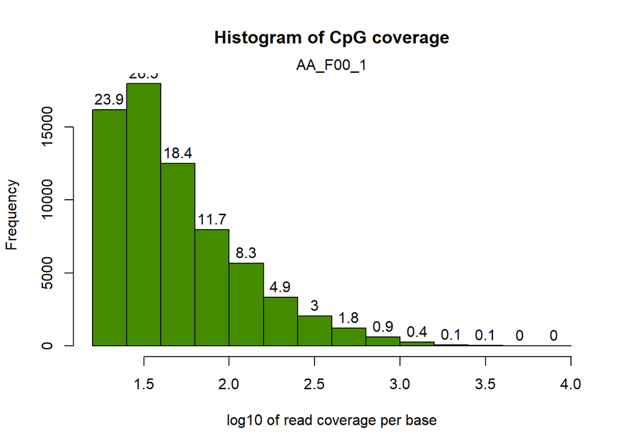

```r
######
# visualize coverage and filter
######

# We can look at the coverage for individual samples with getCoverageStats()
getCoverageStats(myobj[[1]], plot = TRUE, both.strands = FALSE) #Get CpG coverage information
```

```r
# numbers on bars denote what percentage of locations are contained in that bin
# Experiments that are highly suffering from PCR duplication bias will have
# a secondary peak towards the right hand side of the histogram

myobj[[1]] # no. of Cs and Ts should equal coverage
```

```
## methylRawDB object with 67815 rows
## --------------
##          chr start   end strand coverage numCs numTs
## 1 LS041577.1 13445 13445      *       24     0    24
## 2 LS041577.1 13454 13454      *       24     1    23
## 3 LS041577.1 13457 13457      *       24     0    24
## 4 LS041577.1 13469 13469      *       24     0    24
## 5 LS041577.1 13472 13472      *       24     0    24
## 6 LS041577.1 13490 13490      *       23     0    23
## --------------
## sample.id: AA_F00_1
## assembly: atonsa
## context: CpG
## resolution: base
## dbtype: tabix
```

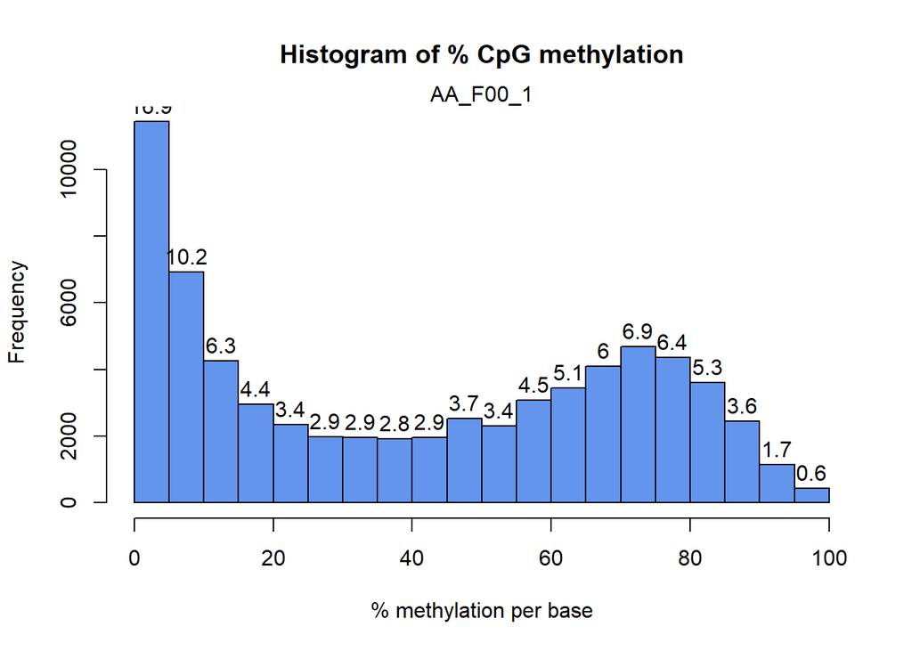

```r
# looking at percent methylation
getMethylationStats(myobj[[1]],plot=TRUE,both.strands=FALSE)
```

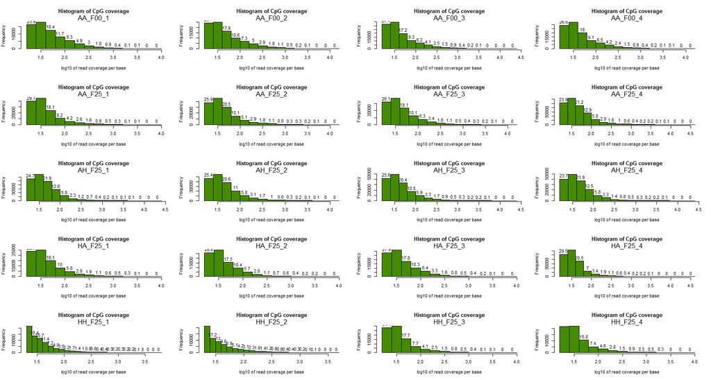

The histogram of CpG coverage for all the samples

```r
# and can plot all of our samples at once to compare.
# par(mfrow=c(5,4))
#
# for(i in 1:length(myobj)) {
#   getCoverageStats(myobj[[i]], plot = TRUE, both.strands = FALSE) #Get CpG coverage information
# } #Plot and save %CpG methylation information
```

```r
# filter samples by depth with filterByCoverage()
filtered.myobj <- filterByCoverage(myobj,
                                   lo.count = 20, lo.perc = NULL,
                                   hi.count = NULL, hi.perc = 97.5,
                                   db.dir = "C:\\Epigenetics_data\\")
```

[output not shown]

[output not shown]

[output not shown]

[output not shown]

[output not shown]

[output not shown]

[output not shown]

[output not shown]

[output not shown]

[output not shown]

[output not shown]

[output not shown]

[output not shown]

[output not shown]

[output not shown]

[output not shown]

[output not shown]

[output not shown]

[output not shown]

[output not shown]

[output not shown]

[output not shown]

[output not shown]

[output not shown]

[output not shown]

[output not shown]

[output not shown]

[output not shown]

[output not shown]

[output not shown]

[output not shown]

[output not shown]

[output not shown]

[output not shown]

[output not shown]

[output not shown]

[output not shown]

[output not shown]

[output not shown]

[output not shown]

[output not shown]

[output not shown]

[output not shown]

[output not shown]

[output not shown]

[output not shown]

[output not shown]

[output not shown]

[output not shown]

[output not shown]

[output not shown]

[output not shown]

[output not shown]

[output not shown]

[output not shown]

[output not shown]

[output not shown]

[output not shown]

[output not shown]

[output not shown]

[output not shown]

[output not shown]

[output not shown]

[output not shown]

[output not shown]

[output not shown]

[output not shown]

[output not shown]

[output not shown]

[output not shown]

[output not shown]

[output not shown]

[output not shown]

[output not shown]

[output not shown]

[output not shown]

[output not shown]

[output not shown]

[output not shown]

[output not shown]

[output not shown]

[output not shown]

[output not shown]

[output not shown]

[output not shown]

[output not shown]

[output not shown]

[output not shown]

[output not shown]

[output not shown]

[output not shown]

[output not shown]

[output not shown]

[output not shown]

[output not shown]

[output not shown]

[output not shown]

[output not shown]

[output not shown]

[output not shown]

[output not shown]

[output not shown]

[output not shown]

[output not shown]

[output not shown]

[output not shown]

[output not shown]

[output not shown]

[output not shown]

[output not shown]

[output not shown]

[output not shown]

[output not shown]

[output not shown]

[output not shown]

[output not shown]

[output not shown]

[output not shown]

[output not shown]

[output not shown]

[output not shown]

[output not shown]

[output not shown]

[output not shown]

[output not shown]

[output not shown]

[output not shown]

[output not shown]

[output not shown]

[output not shown]

[output not shown]

[output not shown]

[output not shown]

[output not shown]

[output not shown]

[output not shown]

[output not shown]

[output not shown]

[output not shown]

[output not shown]

[output not shown]

[output not shown]

[output not shown]

[output not shown]

[output not shown]

[output not shown]

[output not shown]

[output not shown]

[output not shown]

[output not shown]

[output not shown]

[output not shown]

[output not shown]

[output not shown]

[output not shown]

[output not shown]

[output not shown]

[output not shown]

[output not shown]

[output not shown]

```r
######
# merge samples
######

#Note! This takes a while and we're skipping it

# use unite() to merge all the samples. We will require sites to be present in each sample or else will drop it

# don't run as it takes a lot of time
# meth <- unite(filtered.myobj,
#                mc,cores=3,
#                suffix="united", # add united at the end of the name
#                db.dir="C:\\Epigenetics_data\\")
```

Methylkit has a convenient aspect where we can load previously generated databases. This means we don’t have to re-run analyses, but can skip ahead to where we previously left off. We will do this below to load the united database that I’ve already generated.

```r
meth <- methylKit:::readMethylBaseDB(
                      dbpath = "C:\\Epigenetics_data\\Epigenetics_data\\methylBase_united.txt.bgz",
                            dbtype = "tabix",
                            sample.id =   unlist(nmlist),
                            assembly = "atonsa", # this is just a string. not an actual database
                            context = "CpG",
                            resolution = "base",
                            treatment = c(0,0,0,0,
                              1,1,1,1,
                              2,2,2,2,
                              3,3,3,3,
                              4,4,4,4),
                            destrand = FALSE)
```

## Methylation statistics across samples

```r
# percMethylation() calculates the percent methylation for each site and sample
pm <- percMethylation(meth)
head(pm) # methylation percentage for each site per each sample
```

```
##      AA_F00_1 AA_F00_2 AA_F00_3 AA_F00_4  AA_F25_1  AA_F25_2  AA_F25_3
## [1,] 0.000000 5.000000 7.692308 2.564103  1.123596 3.0000000 3.9603960
## [2,] 4.166667 2.500000 0.000000 0.000000 10.112360 0.9900990 0.9708738
## [3,] 0.000000 2.564103 3.846154 0.000000  3.370787 0.9803922 0.9615385
## [4,] 0.000000 2.500000 3.846154 0.000000  1.086957 2.9411765 0.0000000
## [5,] 0.000000 2.500000 7.692308 0.000000  1.086957 2.9702970 0.0000000
## [6,] 0.000000 2.500000 3.846154 0.000000  2.150538 0.0000000 1.9417476
##       AA_F25_4  AH_F25_1  AH_F25_2  AH_F25_3  AH_F25_4 HA_F25_1 HA_F25_2
## [1,] 2.8735632 3.6866359 2.2388060 2.5423729 4.1095890 9.375000 2.816901
## [2,] 1.1494253 0.0000000 3.6764706 0.0000000 1.3698630 3.125000 1.408451
## [3,] 1.1494253 0.9090909 0.7407407 0.8474576 2.7397260 0.000000 0.000000
## [4,] 3.9772727 2.2727273 0.7352941 0.0000000 0.6849315 0.000000 0.000000
## [5,] 0.5714286 0.4608295 2.2058824 1.6949153 2.0689655 0.000000 1.408451
## [6,] 3.4090909 1.8348624 0.7299270 0.8403361 1.3698630 4.477612 0.000000
##      HA_F25_3 HA_F25_4 HH_F25_1 HH_F25_2 HH_F25_3 HH_F25_4
## [1,] 3.030303 2.439024 4.761905        0 1.470588 0.000000
## [2,] 0.000000 1.219512 1.190476        0 0.000000 2.083333
## [3,] 1.515152 1.219512 3.571429        0 1.470588 4.166667
## [4,] 0.000000 1.219512 1.190476        0 0.000000 0.000000
## [5,] 0.000000 0.000000 1.204819        0 5.882353 4.166667
## [6,] 2.898551 2.439024 0.000000        0 1.470588 2.083333
```

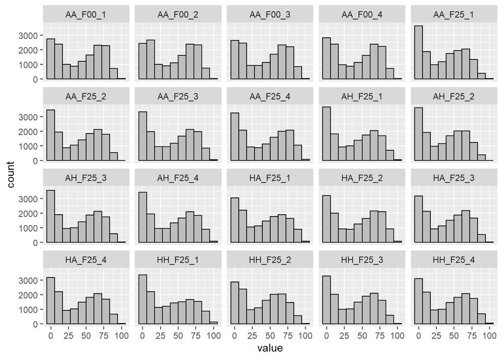

```r
#plot methylation histograms
ggplot(gather(as.data.frame(pm)),
              aes(value)) +
              geom_histogram(bins = 10, color="black", fill="grey") +
              facet_wrap(~key)
```

- none of these are fully methylated  
- biological reason - pools of individuals, so if any slight change in one individual can affect the overall methylation levels for any individual site  
- differenes can also be present because of differenes due to different cell types  
- this U pattern is quite common in model organisms, with high methyaltion at zero and 100, and very low in between  
- The reason could also be technical

```r
# calculate and plot mean methylation
sp.means <- colMeans(pm)

sp.means
```

```
## AA_F00_1 AA_F00_2 AA_F00_3 AA_F00_4 AA_F25_1 AA_F25_2 AA_F25_3 AA_F25_4
## 41.09502 41.61804 41.50262 40.83576 36.30440 38.37196 39.92734 40.73100
## AH_F25_1 AH_F25_2 AH_F25_3 AH_F25_4 HA_F25_1 HA_F25_2 HA_F25_3 HA_F25_4
## 38.25740 36.03000 38.19356 39.57069 39.13568 40.87818 38.46266 38.78108
## HH_F25_1 HH_F25_2 HH_F25_3 HH_F25_4
## 37.59602 38.26307 38.42900 39.20101
```

```r
dim(pm) # methlation for 15158 sites in 20 samples
```

```
## [1] 15158    20
```

```
## No summary function supplied, defaulting to `mean_se()`
```

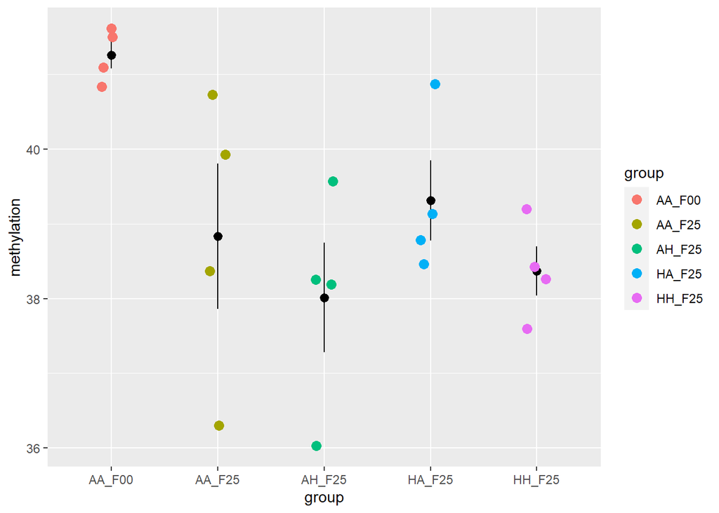

```r
p.df <- data.frame(sample=names(sp.means),
          group = substr(names(sp.means), 1,6),
          methylation = sp.means)

ggplot(p.df, aes(x=group, y=methylation, color=group)) +
    stat_summary(color="black") + geom_jitter(width=0.1, size=3)
```

```r
## is the high methylation rate high in AA_F00 or is it due to it having higher mapping rate compared to the rest of the samples?? - hard to know
```

- mean and std error are represented in the plot
- methylation rate is higher in AA_F00 group
  - is this due to higher mapping rate that was observed for AA_F00 before
  - hard to know if a better library can lead to higher methylation rate score or tighter distribution with just this set of samples
- mean methylation for each sample means the average methylaton rate across the whole genome or the 15000 sites studied here
  - average of every site per sample
  - we don’t want a large varation across the means
- in response to an environmental conditions the global methylation rate can increase or decrease; is there a genome wide response to being in the lab for 25 generations

## Summarize variation: PCA, clustering

**PCA**

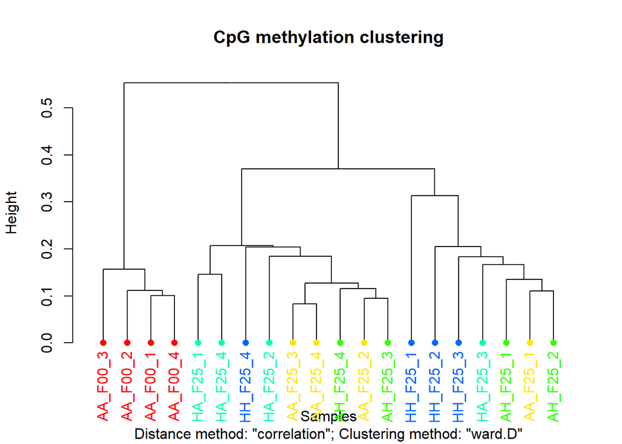

```
##
## Call:
## hclust(d = d, method = HCLUST.METHODS[hclust.method])
##
## Cluster method   : ward.D
## Distance         : pearson
## Number of objects: 20
```

```r
# sample clustering
# looking for similarities and differences between the samples / treatments
clusterSamples(meth,
               dist = "correlation",
               method = "ward.D",
               plot = TRUE)
```

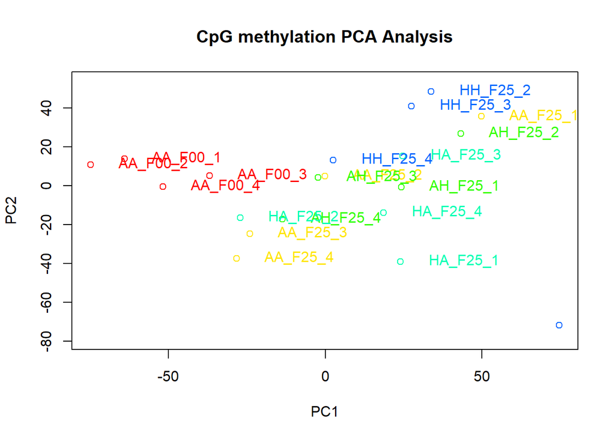

```r
# they are not clustering by treatments
# F00 samples are clustering together  but not so much in other treatments

# PCA
PCASamples(meth)
```

```r
# similarly messy
```

**find differentially methylated sites between two groups**

```r
# subset with reorganize()

meth_sub <- reorganize(meth,
                sample.ids =c("AA_F00_1","AA_F00_2","AA_F00_3", "AA_F00_4",
                              "HH_F25_1","HH_F25_2","HH_F25_3","HH_F25_4"),
                treatment = c(0,0,0,0,1,1,1,1), # subsetting to just 8 samples
                save.db=FALSE)

# calculate differential methylation

myDiff <- calculateDiffMeth(meth_sub,
                            overdispersion = "MN",
                            mc.cores = 1,
                            suffix = "AA_HH",
                            adjust = "qvalue", # FDR correction - commonly applied to genomic analysis
                            test = "Chisq") # chi square
```

```
## two groups detected:
##  will calculate methylation difference as the difference of
## treatment (group: 1) - control (group: 0)
```

```r
# this model of overdispersion and test statistic seems to be the best
```

- fit a logistic regression to methylation values where explanatory variable is the treatment (case or control).
  - and we compare the fit of the model with explanatory variable vs the null model (no explanatory variable) and ask if the fit is better using a Chisq test.
- the methylation proportions are weighted by their coverage, as in a typical logistic regression. Note that in theory you could enter these as two column success and failure data frame, which is common in logistic regressions.
- use overdispersion: Chisq without overdispersion finds more true positives, but many more false positives. good compromise is `overdispersion with Chisq`.
  - reduced true pos, but really reduces false pos rate.

```r
# get all differentially methylated bases
myDiff <- getMethylDiff(myDiff,
                        qvalue = 0.05, # taking out only the significant ones
                        difference = 10) # methylation differences that is taken to count as significant
# 10 is an arbitary number- it can range from 10 to 25%

# we can visualize the changes in methylation frequencies quickly.

head(getData(myDiff)$meth.diff)
```

```
## [1] -10.16196 -17.85524 -13.96676 -13.15037  10.08852  10.08054
```

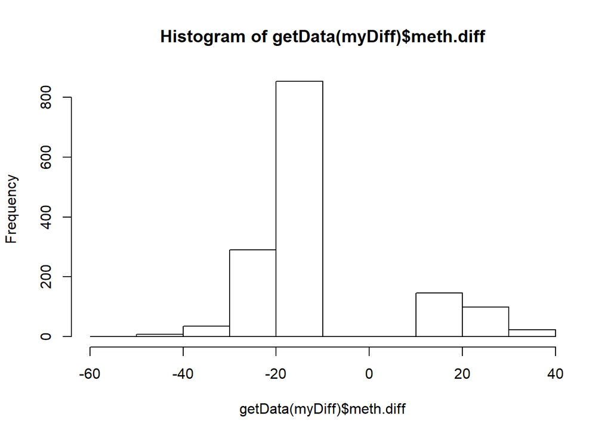

```r
hist(getData(myDiff)$meth.diff) # methylation differences
```

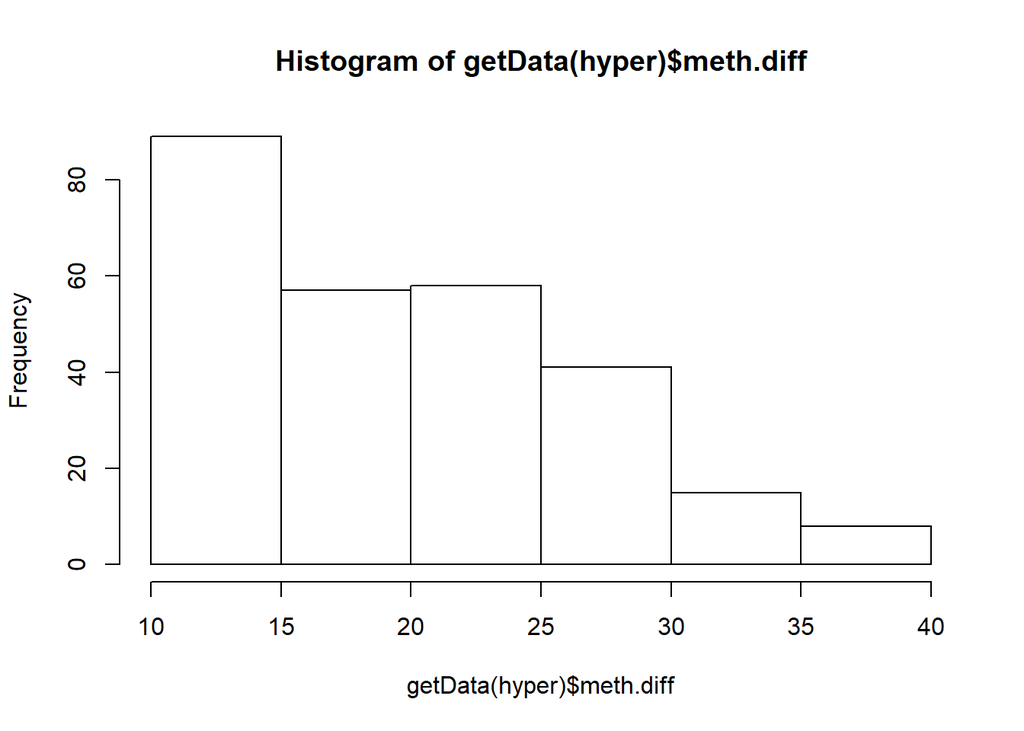

```r
# hist before zero towards the left are hypomethylated and those towards the right are hypermethylated
# we see a lower methylation % in HH samples compared to AA saples

# get hyper methylated bases
hyper=getMethylDiff(myDiff,difference=10,qvalue=0.05,type="hyper")
hist(getData(hyper)$meth.diff)
```

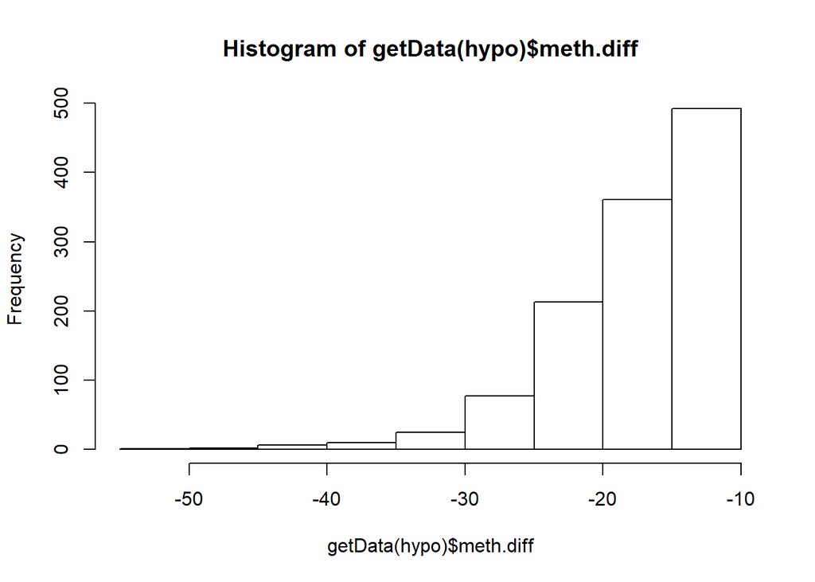

```r
# get hypo methylated bases
hypo=getMethylDiff(myDiff,difference=10,qvalue=0.05,type="hypo")
hist(getData(hypo)$meth.diff)
```

## Plots of differentially methylated groups

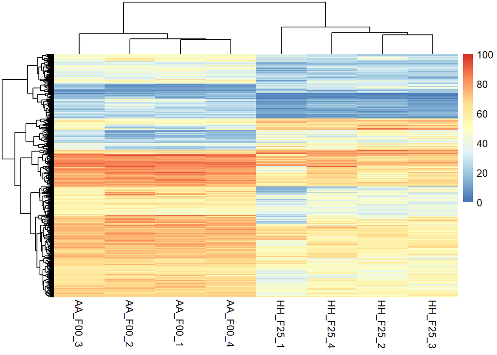

```r
#heatmaps first
pm <- percMethylation(meth_sub)

# make a dataframe with snp id's, methylation, etc.
sig.in <- as.numeric(row.names(myDiff))
pm.sig <- pm[sig.in,]

# add snp, chr, start, stop
din <- getData(myDiff)[,1:3]
df.out <- cbind(paste(getData(myDiff)$chr,
                      getData(myDiff)$start, sep=":"),
                din, pm.sig)
colnames(df.out) <- c("snp",
                      colnames(din),
                      colnames(df.out[5:ncol(df.out)]))
df.out <- (cbind(df.out,getData(myDiff)[,5:7]))

####
# heatmap
####

my_heatmap <- pheatmap(pm.sig,
        show_rownames = FALSE) # red is higher methylation
```

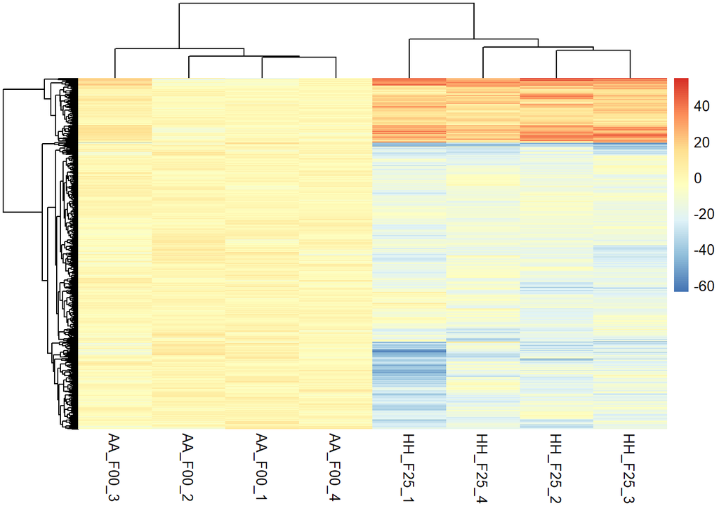

```r
# we can also normalize
ctrmean <- rowMeans(pm.sig[,1:4])

h.norm <- (pm.sig-ctrmean)

my_heatmap <- pheatmap(h.norm,
        show_rownames = FALSE)
```

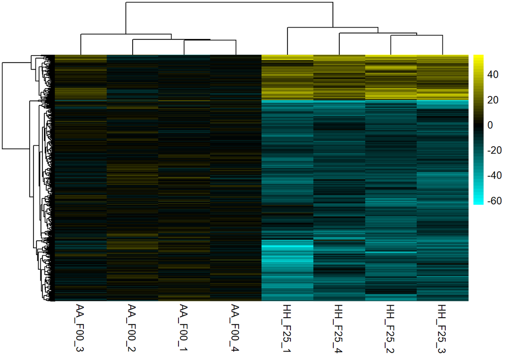

```r
##### if you want to change colors. only because I don't love the default colors.

paletteLength <- 50
myColor <- colorRampPalette(c("cyan1", "black", "yellow1"))(paletteLength)
myBreaks <- c(seq(min(h.norm), 0, length.out=ceiling(paletteLength/2) + 1),
              seq(max(h.norm)/paletteLength, max(h.norm), length.out=floor(paletteLength/2)))

my_heatmap <- pheatmap(h.norm,
        color=myColor,
        breaks=myBreaks,
        show_rownames = FALSE)
```

```r
#####
#let's look at methylation of specific snps
####

# convert data frame to long form
head(df.out,3)
```

```
##               snp        chr start end AA_F00_1 AA_F00_2 AA_F00_3 AA_F00_4
## 23 LS041600.1:376 LS041600.1   376 376 84.37500 83.97436 84.28571 83.57143
## 29 LS041600.1:475 LS041600.1   475 475 77.89474 75.00000 89.04110 80.55556
## 58  LS042377.1:90 LS042377.1    90  90 61.85286 59.91903 58.59155 58.15085
##    HH_F25_1 HH_F25_2 HH_F25_3 HH_F25_4       pvalue       qvalue meth.diff
## 23 76.66667 77.47748 70.17544 70.00000 6.463564e-04 0.0086976959 -10.16196
## 29 45.45455 66.03774 67.50000 68.62745 3.809827e-03 0.0291370853 -17.85524
## 58 53.57143 46.09929 40.42553 49.15254 4.128226e-06 0.0002458728 -13.96676
```

```r
df.plot <- df.out[,c(1,5:12)] %>%
                pivot_longer(-snp, values_to = "methylation")

df.plot$group <- substr(df.plot$name,1,2)
head(df.plot)
```

```
## # A tibble: 6 x 4
##   snp            name     methylation group
##   <fct>          <chr>          <dbl> <chr>
## 1 LS041600.1:376 AA_F00_1        84.4 AA
## 2 LS041600.1:376 AA_F00_2        84.0 AA
## 3 LS041600.1:376 AA_F00_3        84.3 AA
## 4 LS041600.1:376 AA_F00_4        83.6 AA
## 5 LS041600.1:376 HH_F25_1        76.7 HH
## 6 LS041600.1:376 HH_F25_2        77.5 HH
```

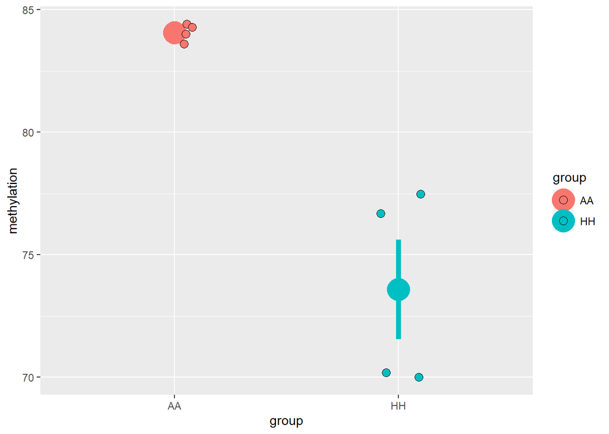

```r
# looking at snp LS041600.1:376

df.plot %>% filter(snp=="LS041600.1:376") %>%
            ggplot(., aes(x=group, y=methylation, color=group, fill=group)) +
              stat_summary(fun.data = "mean_se", size = 2) +
              geom_jitter(width = 0.1, size=3, pch=21, color="black")
```

```r
## write bed file for intersection with genome annotation
write.table(file = "C:\\Epigenetics_data\\Epigenetics_data\\bed_files\\diffmeth.bed",
          data.frame(chr= df.out$chr, start = df.out$start, end = df.out$end),
          row.names=FALSE, col.names=FALSE, quote=FALSE, sep="\t")
```

## Link to genes

**code template**  
- first path –> the location of the package stored - bedtools  
- `closest` - function in bedtools calling for closest features between samples  
- [more details here](https://bedtools.readthedocs.io/en/latest/content/tools/closest.html)  
- > hits.bed - assigning name to the output file

```bash
/data/popgen/bedtools2/bin/bedtools closest -a DIFF.bedFILELOCATION \
      -b /data/project_data/epigenetics/GCA_900241095.1_Aton1.0_genomic.fa_annotation_table.bed \
      -D b | \
      awk '!($10=="-")' > hits.bed
```

```bash
# the annotation file here has the format: ScaffoldName  FromPosition  ToPosition  Sense TranscriptName  TranscriptPath  GeneAccession GeneName  GeneAltNames  GenePfam  GeneGo  CellularComponent MolecularFunction BiologicalProcess

# note that the hits.bed file will paste the diffmeth.bed file before the annotation table. So the first 3 columns are fom diffmeth.bed, then next 8 from the annotation table.

# count up number of hits

cat hits.bed | wc -l

# count number of unique named genes
cat hits.bed | cut -f 8 | sort | uniq -c
```

# Experiment

## AA_F25 and AH_F25

**find differentially methylated sites between two groups**

```r
# subset with reorganize()

meth_sub <- reorganize(meth,
                sample.ids =c("AA_F25_1","AA_F25_2","AA_F25_3", "AA_F25_4",
                              "AH_F25_1","AH_F25_2","AH_F25_3","AH_F25_4"),
                treatment = c(0,0,0,0,1,1,1,1), # subsetting to just 8 samples
                save.db=FALSE)

# calculate differential methylation
myDiff <- calculateDiffMeth(meth_sub,
                            overdispersion = "MN",
                            mc.cores = 1,
                            suffix = "AA_AH",
                            adjust = "qvalue",
                            test = "Chisq")
```

```
## two groups detected:
##  will calculate methylation difference as the difference of
## treatment (group: 1) - control (group: 0)
```

```r
# get all differentially methylated bases
myDiff <- getMethylDiff(myDiff,
                        qvalue = 0.05,
                        difference = 10)

head(getData(myDiff)$meth.diff)
```

```
## [1] -13.38261 -12.50014  16.57960 -10.85679 -11.15066 -11.61221
```

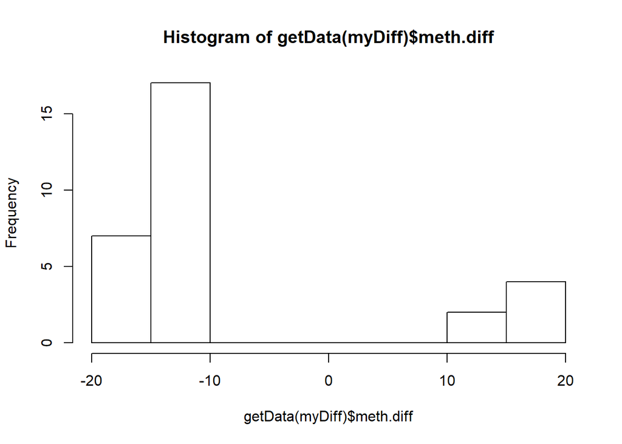

```r
hist(getData(myDiff)$meth.diff) # methylation differences
```

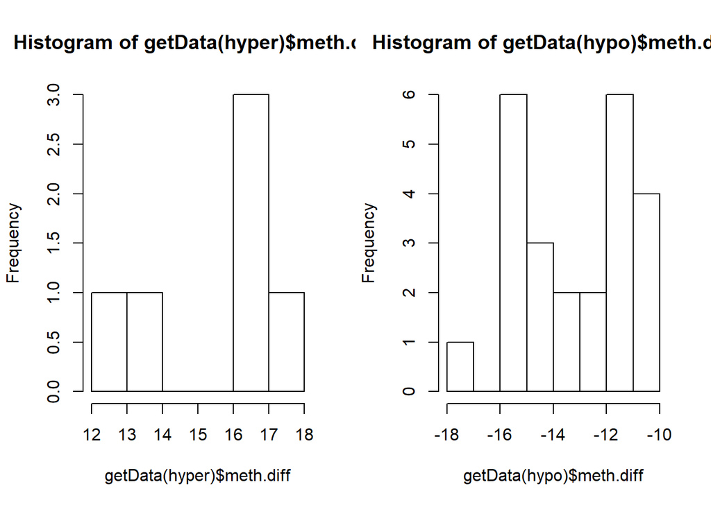

```r
# hist before zero towards the left are hypomethylated and those towards the right are hypermethylated
# we see a lower methylation % in AH_F25 samples compared to AA_F25 samples

# get hyper methylated bases
hyper=getMethylDiff(myDiff,difference=10,qvalue=0.05,type="hyper")

# get hypo methylated bases
hypo=getMethylDiff(myDiff,difference=10,qvalue=0.05,type="hypo")

par(mfrow=c(1,2))
hist(getData(hyper)$meth.diff)
hist(getData(hypo)$meth.diff)
```

```r
par(mfrow=c(1,2))
```

**Plots of differentially methylated groups**

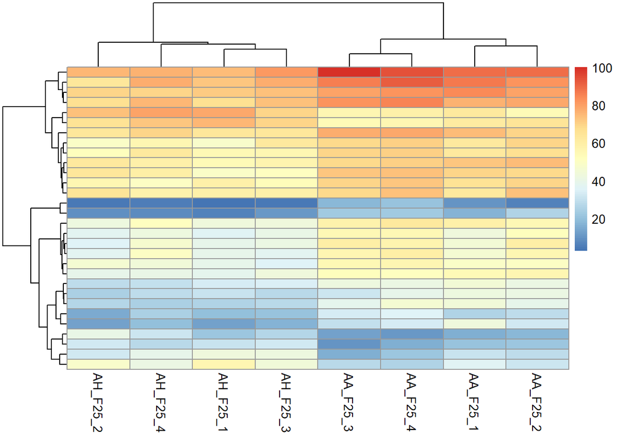

```r
#heatmaps first
pm <- percMethylation(meth_sub)

# make a dataframe with snp id's, methylation, etc.
sig.in <- as.numeric(row.names(myDiff))
pm.sig <- pm[sig.in,]

# add snp, chr, start, stop
din <- getData(myDiff)[,1:3]
df.out <- cbind(paste(getData(myDiff)$chr,
                      getData(myDiff)$start, sep=":"),
                din, pm.sig)
colnames(df.out) <- c("snp",
                      colnames(din),
                      colnames(df.out[5:ncol(df.out)]))
df.out <- (cbind(df.out,getData(myDiff)[,5:7]))

####
# heatmap
####

my_heatmap <- pheatmap(pm.sig,
        show_rownames = FALSE) # red is higher methylation
```

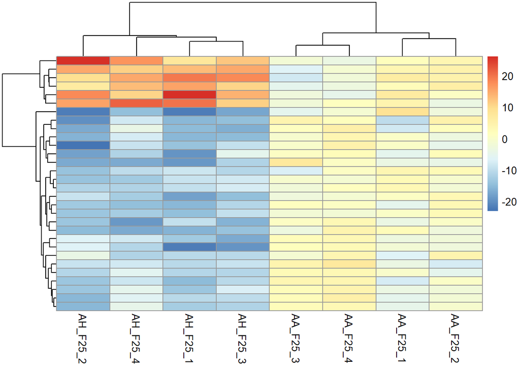

```r
# we can also normalize
ctrmean <- rowMeans(pm.sig[,1:4])

h.norm <- (pm.sig-ctrmean)

my_heatmap <- pheatmap(h.norm,
        show_rownames = FALSE)
```

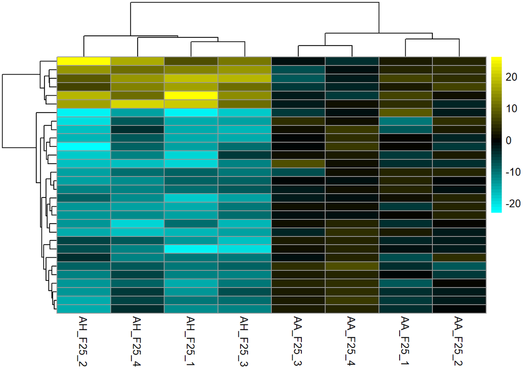

```r
##### Recoloring the heatmaps.
paletteLength <- 50
myColor <- colorRampPalette(c("cyan1", "black", "yellow1"))(paletteLength)
myBreaks <- c(seq(min(h.norm), 0, length.out=ceiling(paletteLength/2) + 1),
              seq(max(h.norm)/paletteLength, max(h.norm), length.out=floor(paletteLength/2)))

my_heatmap <- pheatmap(h.norm,
        color=myColor,
        breaks=myBreaks,
        show_rownames = FALSE)
```

```r
#####
#let's look at methylation of specific snps
####

# convert data frame to long form
head(df.out,3)
```

```
##                  snp        chr start  end AA_F25_1 AA_F25_2 AA_F25_3 AA_F25_4
## 1965 LS051659.1:1214 LS051659.1  1214 1214 62.50000 69.79866 68.31683 70.14218
## 2251  LS053241.1:414 LS053241.1   414  414 42.34694 41.46341 31.70732 39.47368
## 3451 LS068114.1:6322 LS068114.1  6322 6322 30.35714 28.57143 15.73034 21.60494
##      AH_F25_1 AH_F25_2 AH_F25_3 AH_F25_4       pvalue     qvalue meth.diff
## 1965 48.33333 49.47368 62.40602 56.06061 5.298836e-05 0.04100001 -13.38261
## 2251 30.18868 24.83660 27.77778 28.57143 1.235214e-04 0.04468703 -12.50014
## 3451 43.44262 33.00000 42.02899 39.13043 1.789182e-05 0.02076583  16.57960
```

```r
df.plot <- df.out[,c(1,5:12)] %>%
                pivot_longer(-snp, values_to = "methylation")

df.plot$group <- substr(df.plot$name,1,2)
head(df.plot)
```

```
## # A tibble: 6 x 4
##   snp             name     methylation group
##   <fct>           <chr>          <dbl> <chr>
## 1 LS051659.1:1214 AA_F25_1        62.5 AA
## 2 LS051659.1:1214 AA_F25_2        69.8 AA
## 3 LS051659.1:1214 AA_F25_3        68.3 AA
## 4 LS051659.1:1214 AA_F25_4        70.1 AA
## 5 LS051659.1:1214 AH_F25_1        48.3 AH
## 6 LS051659.1:1214 AH_F25_2        49.5 AH
```

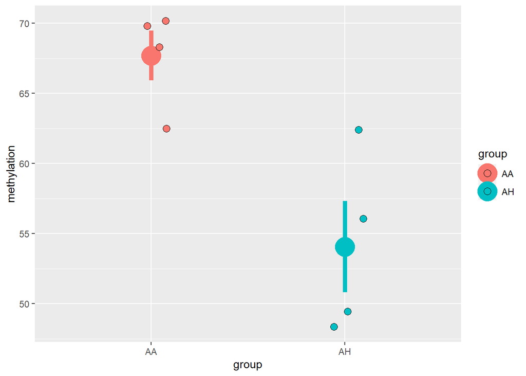

```r
# looking at snp LS051659.1:1214

df.plot %>% filter(snp=="LS051659.1:1214") %>%
            ggplot(., aes(x=group, y=methylation, color=group, fill=group)) +
              stat_summary(fun.data = "mean_se", size = 2) +
              geom_jitter(width = 0.1, size=3, pch=21, color="black")
```

```r
## write bed file for intersection with genome annotation
write.table(file = "C:\\Epigenetics_data\\Epigenetics_data\\bed_files\\AA_AH_diffmeth.bed",
          data.frame(chr= df.out$chr, start = df.out$start, end = df.out$end),
          row.names=FALSE, col.names=FALSE, quote=FALSE, sep="\t")
```

**Link to genes**

```bash
/data/popgen/bedtools2/bin/bedtools closest -a /users/a/p/ap1/EcologicalGenomics/myresults/bedfiles_copepod/AA_AH_diffmeth.bed\
      -b /data/project_data/epigenetics/GCA_900241095.1_Aton1.0_genomic.fa_annotation_table.bed \
      -D b | \
      awk '!($10=="-")' > AA_AH_hits.bed # save filename is hits.bed
```

```bash
# count up number of hits

cat AA_AH_hits.bed | wc -l #18

# count number of unique named genes
cat AA_AH_hits.bed | cut -f 8 | sort | uniq -c
```

## AA_F25 and HH_F25

**find differentially methylated sites between two groups**

```r
# subset with reorganize()

meth_sub <- reorganize(meth,
                sample.ids =c("AA_F25_1","AA_F25_2","AA_F25_3", "AA_F25_4",
                              "HH_F25_1","HH_F25_2","HH_F25_3","HH_F25_4"),
                treatment = c(0,0,0,0,1,1,1,1), # subsetting to just 8 samples
                save.db=FALSE)

# calculate differential methylation
myDiff <- calculateDiffMeth(meth_sub,
                            overdispersion = "MN",
                            mc.cores = 1,
                            suffix = "AA_HH",
                            adjust = "qvalue",
                            test = "Chisq")
```

```
## two groups detected:
##  will calculate methylation difference as the difference of
## treatment (group: 1) - control (group: 0)
```

```r
# get all differentially methylated bases
myDiff <- getMethylDiff(myDiff,
                        qvalue = 0.05,
                        difference = 10)

head(getData(myDiff)$meth.diff)
```

```
## [1]  12.36264 -13.76137  31.97324  32.09734  10.66545  10.84294
```

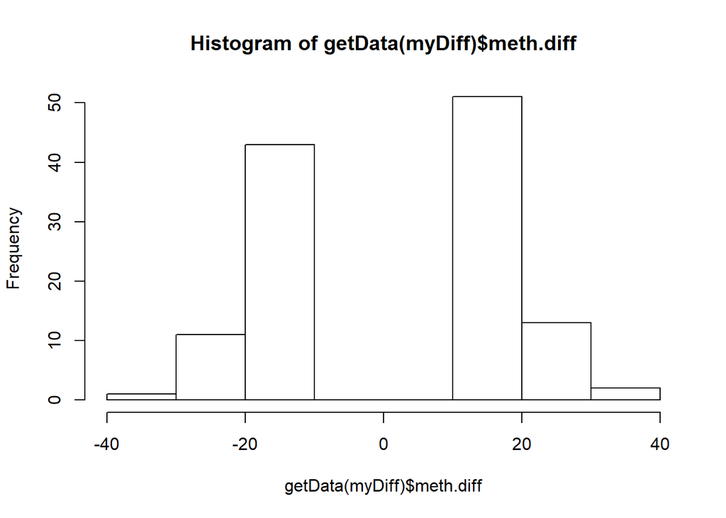

```r
hist(getData(myDiff)$meth.diff) # methylation differences
```

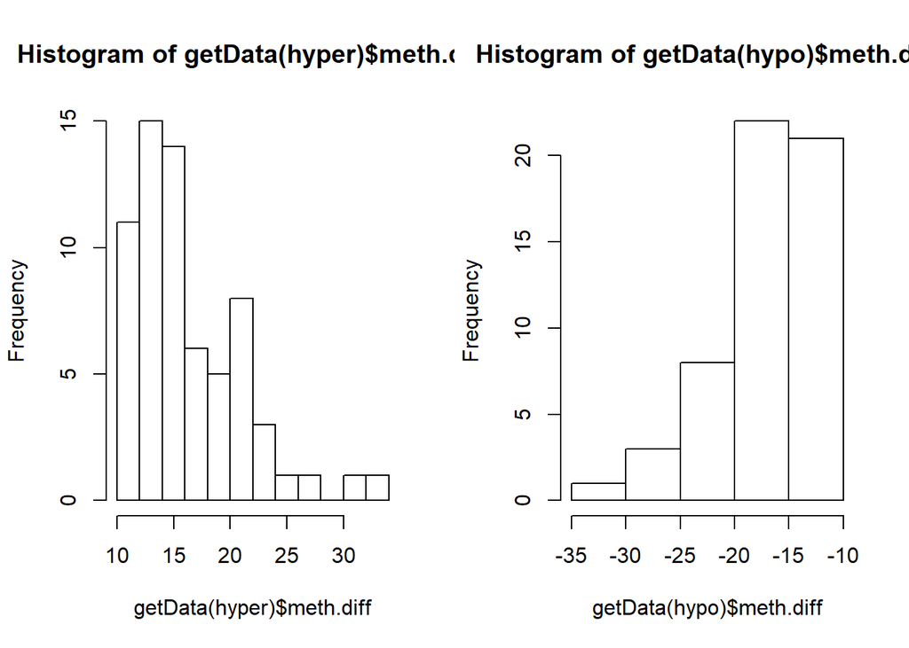

```r
# hist before zero towards the left are hypomethylated and those towards the right are hypermethylated
# we see a sightly higher methylation % in HH_F25 samples compared to AA_F25 samples

# get hyper methylated bases
hyper=getMethylDiff(myDiff,difference=10,qvalue=0.05,type="hyper")

# get hypo methylated bases
hypo=getMethylDiff(myDiff,difference=10,qvalue=0.05,type="hypo")

par(mfrow=c(1,2))
hist(getData(hyper)$meth.diff)
hist(getData(hypo)$meth.diff)
```

```r
par(mfrow=c(1,2))
```

**Plots of differentially methylated groups**

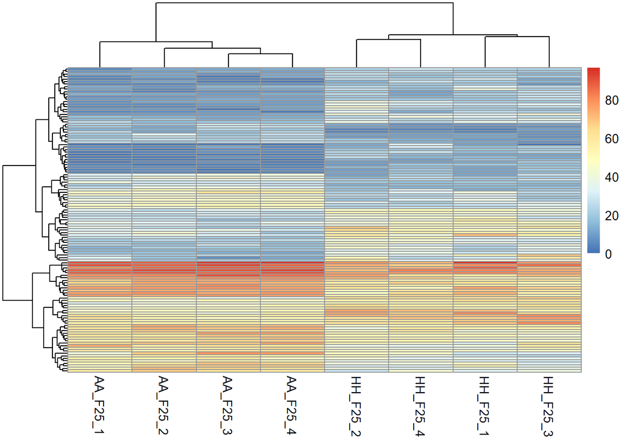

```r
#heatmaps first
pm <- percMethylation(meth_sub)

# make a dataframe with snp id's, methylation, etc.
sig.in <- as.numeric(row.names(myDiff))
pm.sig <- pm[sig.in,]

# add snp, chr, start, stop
din <- getData(myDiff)[,1:3]
df.out <- cbind(paste(getData(myDiff)$chr,
                      getData(myDiff)$start, sep=":"),
                din, pm.sig)
colnames(df.out) <- c("snp",
                      colnames(din),
                      colnames(df.out[5:ncol(df.out)]))
df.out <- (cbind(df.out,getData(myDiff)[,5:7]))

####
# heatmap
####

my_heatmap <- pheatmap(pm.sig,
        show_rownames = FALSE) # red is higher methylation
```